# R Notebook Kira Plastina

## 1.3 Loading Data

```r
# Loading the Dataset
kira = read.csv('http://bit.ly/EcommerceCustomersDataset')
head(kira)
```

|  | Administrative | Administrative_Duration | Informational | Informational_Duration | ProductRelated | ProductRelated_Duration | BounceRates | ExitRates | PageValues | SpecialDay | Month | OperatingSystems | Browser | Region | TrafficType | VisitorType | Weekend | Revenue |
| --- | --- | --- | --- | --- | --- | --- | --- | --- | --- | --- | --- | --- | --- | --- | --- | --- | --- | --- |
| 1 | 0 | 0 | 0 | 0 | 1 | 0.000000 | 0.20000000 | 0.2000000 | 0 | 0 | Feb | 1 | 1 | 1 | 1 | Returning_Visitor | FALSE | FALSE |
| 2 | 0 | 0 | 0 | 0 | 2 | 64.000000 | 0.00000000 | 0.1000000 | 0 | 0 | Feb | 2 | 2 | 1 | 2 | Returning_Visitor | FALSE | FALSE |
| 3 | 0 | -1 | 0 | -1 | 1 | -1.000000 | 0.20000000 | 0.2000000 | 0 | 0 | Feb | 4 | 1 | 9 | 3 | Returning_Visitor | FALSE | FALSE |
| 4 | 0 | 0 | 0 | 0 | 2 | 2.666667 | 0.05000000 | 0.1400000 | 0 | 0 | Feb | 3 | 2 | 2 | 4 | Returning_Visitor | FALSE | FALSE |
| 5 | 0 | 0 | 0 | 0 | 10 | 627.500000 | 0.02000000 | 0.0500000 | 0 | 0 | Feb | 3 | 3 | 1 | 4 | Returning_Visitor | TRUE | FALSE |
| 6 | 0 | 0 | 0 | 0 | 19 | 154.216667 | 0.01578947 | 0.0245614 | 0 | 0 | Feb | 2 | 2 | 1 | 3 | Returning_Visitor | FALSE | FALSE |

### 1.3.1 Dataset information

```r
# Dataset information
str(kira)
```

```
## 'data.frame':    12330 obs. of  18 variables:
##  $ Administrative         : int  0 0 0 0 0 0 0 1 0 0 ...
##  $ Administrative_Duration: num  0 0 -1 0 0 0 -1 -1 0 0 ...
##  $ Informational          : int  0 0 0 0 0 0 0 0 0 0 ...
##  $ Informational_Duration : num  0 0 -1 0 0 0 -1 -1 0 0 ...
##  $ ProductRelated         : int  1 2 1 2 10 19 1 1 2 3 ...
##  $ ProductRelated_Duration: num  0 64 -1 2.67 627.5 ...
##  $ BounceRates            : num  0.2 0 0.2 0.05 0.02 ...
##  $ ExitRates              : num  0.2 0.1 0.2 0.14 0.05 ...
##  $ PageValues             : num  0 0 0 0 0 0 0 0 0 0 ...
##  $ SpecialDay             : num  0 0 0 0 0 0 0.4 0 0.8 0.4 ...
##  $ Month                  : Factor w/ 10 levels "Aug","Dec","Feb",..: 3 3 3 3 3 3 3 3 3 3 ...
##  $ OperatingSystems       : int  1 2 4 3 3 2 2 1 2 2 ...
##  $ Browser                : int  1 2 1 2 3 2 4 2 2 4 ...
##  $ Region                 : int  1 1 9 2 1 1 3 1 2 1 ...
##  $ TrafficType            : int  1 2 3 4 4 3 3 5 3 2 ...
##  $ VisitorType            : Factor w/ 3 levels "New_Visitor",..: 3 3 3 3 3 3 3 3 3 3 ...
##  $ Weekend                : logi  FALSE FALSE FALSE FALSE TRUE FALSE ...
##  $ Revenue                : logi  FALSE FALSE FALSE FALSE FALSE FALSE ...
```

*The Kira dataset has 12,330 observations with 18 Variables.*

### 1.3.2 Data summary

```r
# Data summary
summary(kira)
```

```
##  Administrative   Administrative_Duration Informational
##  Min.   : 0.000   Min.   :  -1.00         Min.   : 0.000
##  1st Qu.: 0.000   1st Qu.:   0.00         1st Qu.: 0.000
##  Median : 1.000   Median :   8.00         Median : 0.000
##  Mean   : 2.318   Mean   :  80.91         Mean   : 0.504
##  3rd Qu.: 4.000   3rd Qu.:  93.50         3rd Qu.: 0.000
##  Max.   :27.000   Max.   :3398.75         Max.   :24.000
##  NA's   :14       NA's   :14              NA's   :14
##  Informational_Duration ProductRelated   ProductRelated_Duration
##  Min.   :  -1.00        Min.   :  0.00   Min.   :   -1.0
##  1st Qu.:   0.00        1st Qu.:  7.00   1st Qu.:  185.0
##  Median :   0.00        Median : 18.00   Median :  599.8
##  Mean   :  34.51        Mean   : 31.76   Mean   : 1196.0
##  3rd Qu.:   0.00        3rd Qu.: 38.00   3rd Qu.: 1466.5
##  Max.   :2549.38        Max.   :705.00   Max.   :63973.5
##  NA's   :14             NA's   :14       NA's   :14
##   BounceRates         ExitRates         PageValues        SpecialDay
##  Min.   :0.000000   Min.   :0.00000   Min.   :  0.000   Min.   :0.00000
##  1st Qu.:0.000000   1st Qu.:0.01429   1st Qu.:  0.000   1st Qu.:0.00000
##  Median :0.003119   Median :0.02512   Median :  0.000   Median :0.00000
##  Mean   :0.022152   Mean   :0.04300   Mean   :  5.889   Mean   :0.06143
##  3rd Qu.:0.016684   3rd Qu.:0.05000   3rd Qu.:  0.000   3rd Qu.:0.00000
##  Max.   :0.200000   Max.   :0.20000   Max.   :361.764   Max.   :1.00000
##  NA's   :14         NA's   :14
##      Month      OperatingSystems    Browser           Region
##  May    :3364   Min.   :1.000    Min.   : 1.000   Min.   :1.000
##  Nov    :2998   1st Qu.:2.000    1st Qu.: 2.000   1st Qu.:1.000
##  Mar    :1907   Median :2.000    Median : 2.000   Median :3.000
##  Dec    :1727   Mean   :2.124    Mean   : 2.357   Mean   :3.147
##  Oct    : 549   3rd Qu.:3.000    3rd Qu.: 2.000   3rd Qu.:4.000
##  Sep    : 448   Max.   :8.000    Max.   :13.000   Max.   :9.000
##  (Other):1337
##   TrafficType               VisitorType     Weekend         Revenue
##  Min.   : 1.00   New_Visitor      : 1694   Mode :logical   Mode :logical
##  1st Qu.: 2.00   Other            :   85   FALSE:9462      FALSE:10422
##  Median : 2.00   Returning_Visitor:10551   TRUE :2868      TRUE :1908
##  Mean   : 4.07
##  3rd Qu.: 4.00
##  Max.   :20.00
##
```

## 1.4 Data Cleaning

### 1.4.1 Missing Values

```r
# Checking for Missing Values

colSums(is.na(kira))
```

```
##          Administrative Administrative_Duration           Informational
##                      14                      14                      14
##  Informational_Duration          ProductRelated ProductRelated_Duration
##                      14                      14                      14
##             BounceRates               ExitRates              PageValues
##                      14                      14                       0
##              SpecialDay                   Month        OperatingSystems
##                       0                       0                       0
##                 Browser                  Region             TrafficType
##                       0                       0                       0
##             VisitorType                 Weekend                 Revenue
##                       0                       0                       0
```

There are 8 columns with 14 NA values each. We replace these NA values with the mean of each variable.

```r
library(dplyr)
kira  = mutate(kira,
               Administrative=replace(Administrative,
                                      is.na(Administrative),
                                      mean(Administrative,na.rm=TRUE)))
kira  = mutate(kira,
               Administrative_Duration=replace(Administrative_Duration,
                                               is.na(Administrative_Duration),
                                               mean(Administrative_Duration,na.rm=TRUE)))

kira  = mutate(kira,
               Informational = replace(Informational,
                                       is.na(Informational),
                                       mean(Informational, na.rm = TRUE)))

kira  = mutate(kira,
               Informational_Duration=replace(Informational_Duration,
                                              is.na(Informational_Duration),
                                              mean(Informational_Duration,na.rm=TRUE)))

kira  = mutate(kira,
               ProductRelated=replace(ProductRelated,
                                       is.na(ProductRelated),
                                       mean(ProductRelated,na.rm=TRUE)))
kira  = mutate(kira,
               ProductRelated_Duration=replace(ProductRelated_Duration,
                                               is.na(ProductRelated_Duration),
                                               mean(ProductRelated_Duration, na.rm = TRUE)))
kira  = mutate(kira,
               BounceRates =replace(BounceRates,
                                    is.na(BounceRates),
                                    mean(BounceRates,na.rm=TRUE)))
kira  = mutate(kira,
               ExitRates = replace(ExitRates, is.na(ExitRates), mean(ExitRates, na.rm = TRUE)))
```

```r
# Confirming there are no Missing Values after replacing with mean

colSums(is.na(kira))
```

```
##          Administrative Administrative_Duration           Informational
##                       0                       0                       0
##  Informational_Duration          ProductRelated ProductRelated_Duration
##                       0                       0                       0
##             BounceRates               ExitRates              PageValues
##                       0                       0                       0
##              SpecialDay                   Month        OperatingSystems
##                       0                       0                       0
##                 Browser                  Region             TrafficType
##                       0                       0                       0
##             VisitorType                 Weekend                 Revenue
##                       0                       0                       0
```

There are no missing values after replacing all NA values with respective mean values.

### 1.4.2 Duplicated observations (records)

```r
# Check for duplicated observations
dim(kira)
```

```
## [1] 12330    18
```

```r
dim(kira[duplicated(kira),])
```

```
## [1] 119  18
```

There are 119 out of the total 12330 duplicated observations.

```r
# Remove the 119 duplicated observations
kira_clean <- kira[!duplicated(kira),]
dim(kira_clean)
```

```
## [1] 12211    18
```

The clean dataframe has 12211 observations in total after dropping duplicates.

### 1.4.3 Univariate Analysis - Box Plots

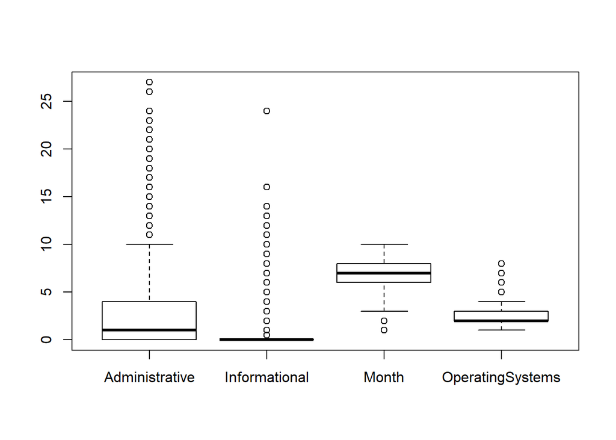

```r
boxplot(kira_clean[c(1,3,11,12)])
```

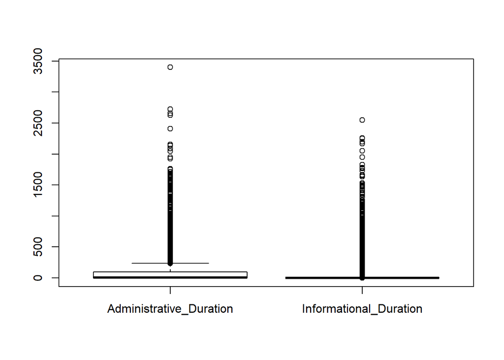

```r
boxplot(kira_clean[c(2,4)])
```

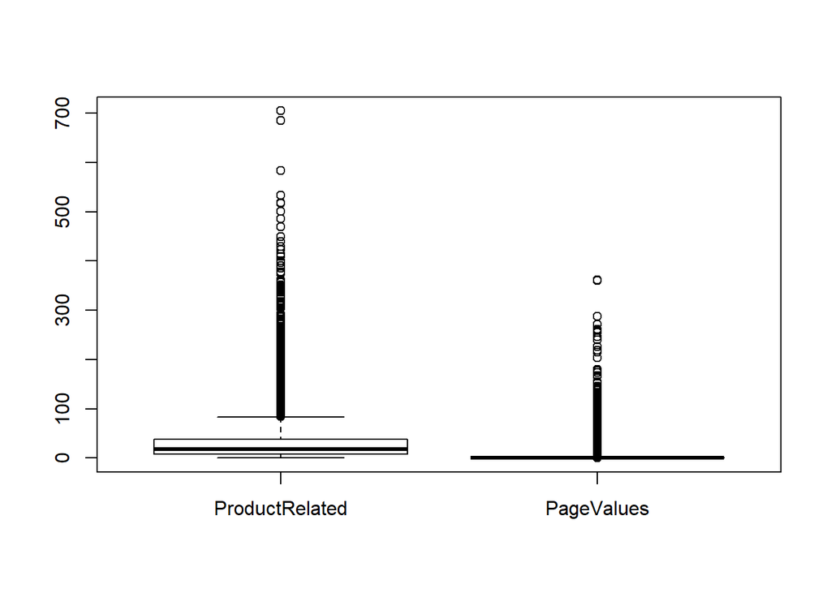

```r
boxplot(kira_clean[c(5,9)])
```

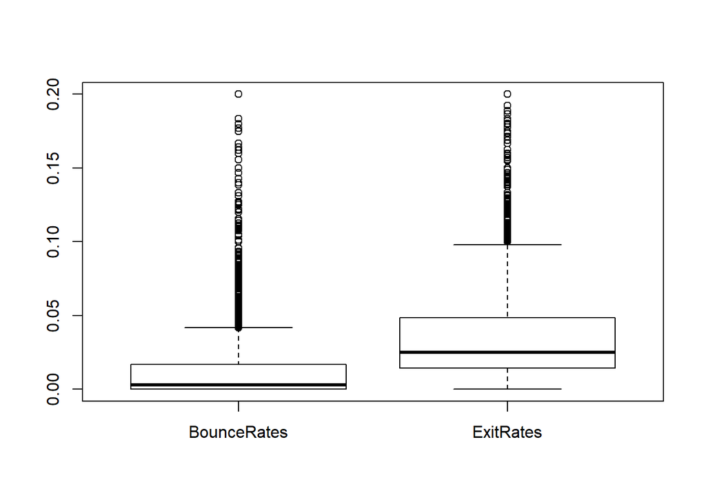

```r
boxplot(kira_clean[7:8])
```

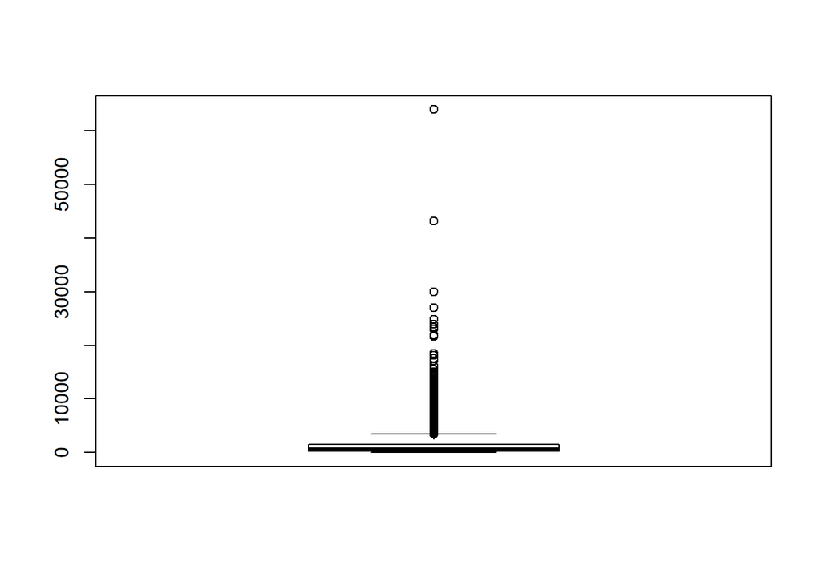

```r
boxplot(kira_clean[6])
```

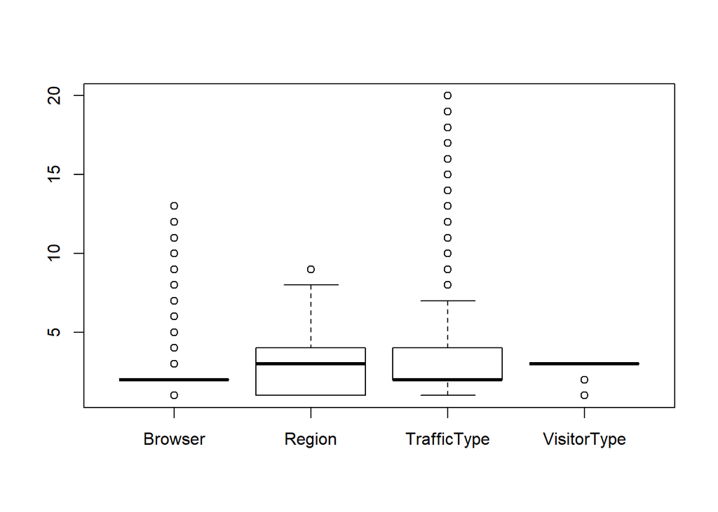

```r
boxplot(kira_clean[c(13,14,15,16)])
```

All the numerical data has outliers. We cannot remove all as it will leave little or no data to work with. We will use all the data to understand customer behaviour.

### 1.4.4 Univariate Analysis - Histograms

```r
library(DataExplorer)
```

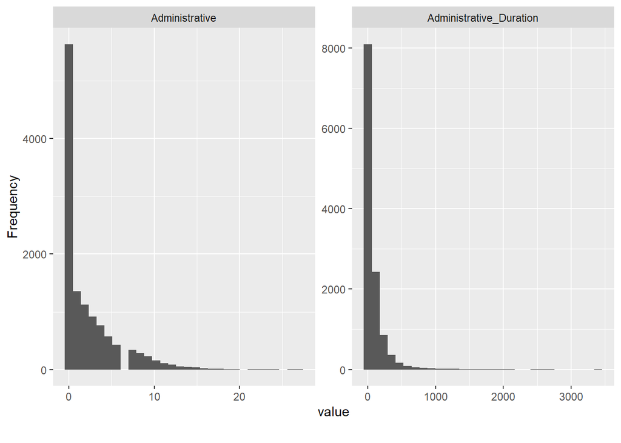

```r
plot_histogram(kira_clean[1:2])
```

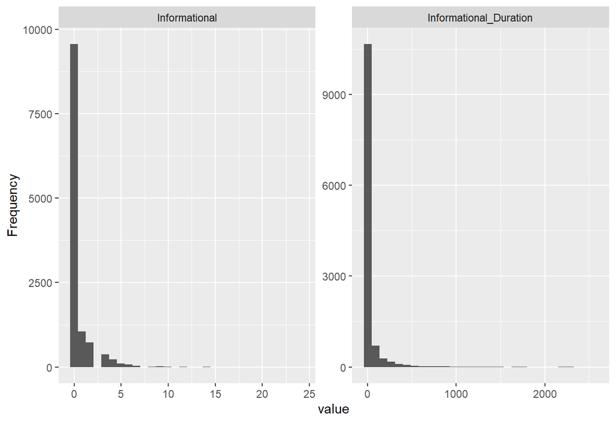

```r
plot_histogram(kira_clean[3:4])
```

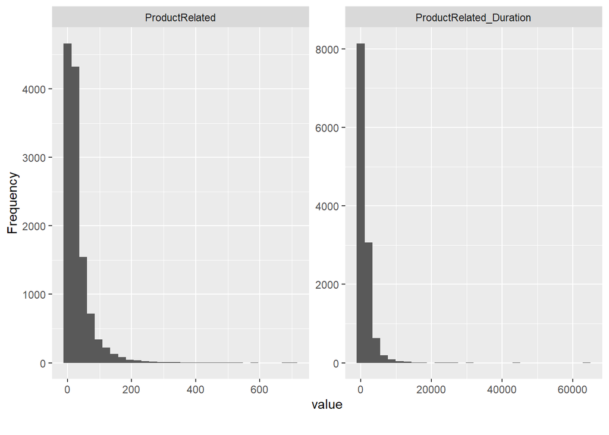

```r
plot_histogram(kira_clean[5:6])
```

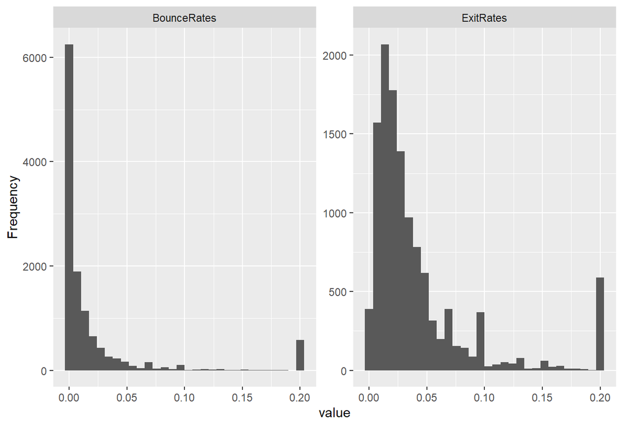

```r
plot_histogram(kira_clean[7:8])
```

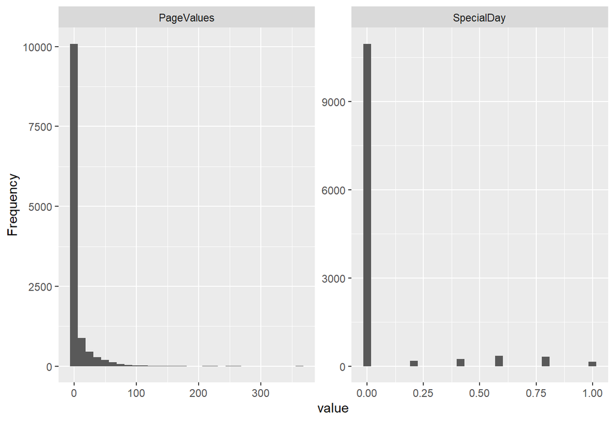

```r
plot_histogram(kira_clean[9:10])
```

All the 10 numerical variables are skewed to the right.

## 1.5 Multivariate Analysis

### 1.5.1 Correlation Matrix

```r
kira_cor <- cor(kira_clean[1:8])
round(kira_cor, digits=2)
```

```
##                         Administrative Administrative_Duration Informational
## Administrative                    1.00                    0.60          0.38
## Administrative_Duration           0.60                    1.00          0.30
## Informational                     0.38                    0.30          1.00
## Informational_Duration            0.25                    0.24          0.62
## ProductRelated                    0.43                    0.29          0.37
## ProductRelated_Duration           0.37                    0.35          0.39
## BounceRates                      -0.21                   -0.14         -0.11
## ExitRates                        -0.31                   -0.20         -0.16
##                         Informational_Duration ProductRelated
## Administrative                            0.25           0.43
## Administrative_Duration                   0.24           0.29
## Informational                             0.62           0.37
## Informational_Duration                    1.00           0.28
## ProductRelated                            0.28           1.00
## ProductRelated_Duration                   0.35           0.86
## BounceRates                              -0.07          -0.19
## ExitRates                                -0.10          -0.29
##                         ProductRelated_Duration BounceRates ExitRates
## Administrative                             0.37       -0.21     -0.31
## Administrative_Duration                    0.35       -0.14     -0.20
## Informational                              0.39       -0.11     -0.16
## Informational_Duration                     0.35       -0.07     -0.10
## ProductRelated                             0.86       -0.19     -0.29
## ProductRelated_Duration                    1.00       -0.17     -0.25
## BounceRates                               -0.17        1.00      0.90
## ExitRates                                 -0.25        0.90      1.00
```

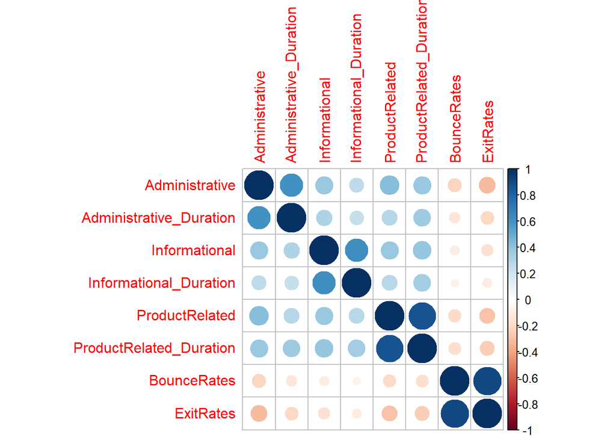

```r
library(corrplot)
corrplot(kira_cor)
```

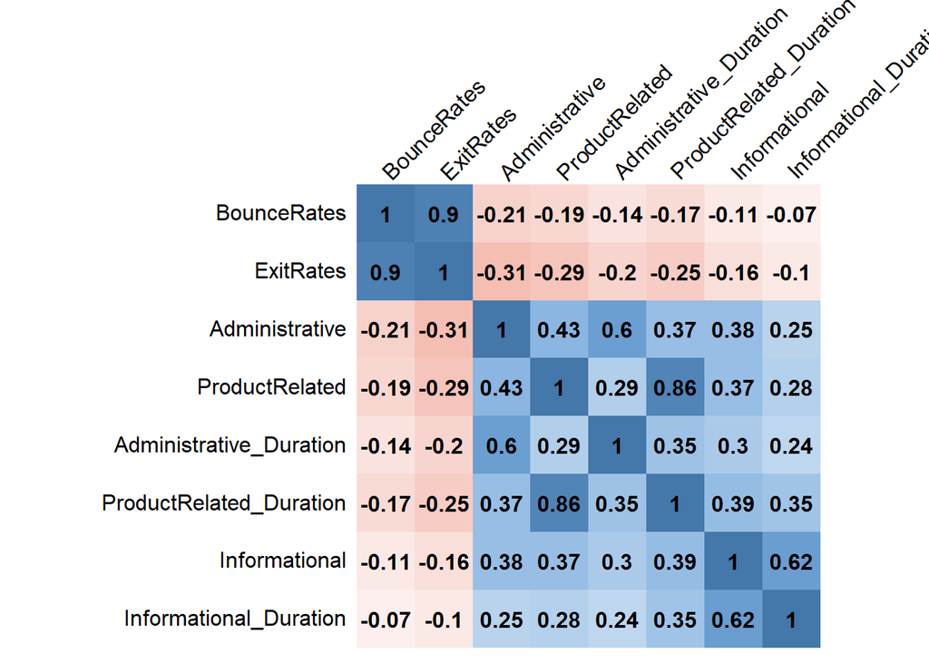

```r
# Generate a lighter palette
col <- colorRampPalette(c("#BB4444", "#EE9988", "#FFFFFF", "#77AADD", "#4477AA"))

corrplot(kira_cor, method = "shade", shade.col = NA, tl.col = "black", tl.srt = 45,
         col = col(200), addCoef.col = "black", cl.pos = "n", order = "AOE")
```

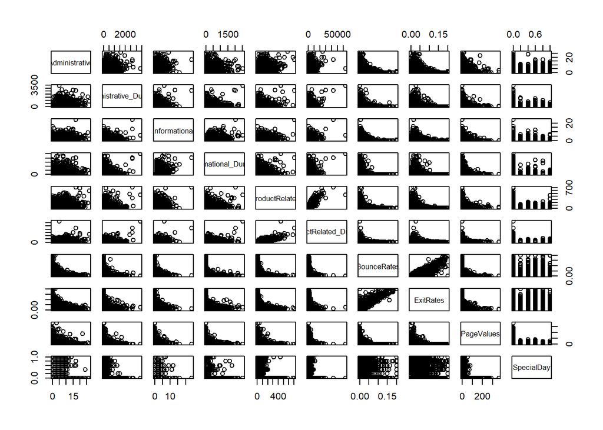

```r
options(repr.plot.width=10, repr.plot.height=10)
pairs(kira_clean[,1:10])
```

## 1.6 K-Means Clustering - Unsupervised Machine Learning

```r
# Checking data types to confirm which ones to be encoded from caterogical to numerical
str(kira_clean)
```

```
## 'data.frame':    12211 obs. of  18 variables:
##  $ Administrative         : num  0 0 0 0 0 0 0 1 0 0 ...
##  $ Administrative_Duration: num  0 0 -1 0 0 0 -1 -1 0 0 ...
##  $ Informational          : num  0 0 0 0 0 0 0 0 0 0 ...
##  $ Informational_Duration : num  0 0 -1 0 0 0 -1 -1 0 0 ...
##  $ ProductRelated         : num  1 2 1 2 10 19 1 1 2 3 ...
##  $ ProductRelated_Duration: num  0 64 -1 2.67 627.5 ...
##  $ BounceRates            : num  0.2 0 0.2 0.05 0.02 ...
##  $ ExitRates              : num  0.2 0.1 0.2 0.14 0.05 ...
##  $ PageValues             : num  0 0 0 0 0 0 0 0 0 0 ...
##  $ SpecialDay             : num  0 0 0 0 0 0 0.4 0 0.8 0.4 ...
##  $ Month                  : Factor w/ 10 levels "Aug","Dec","Feb",..: 3 3 3 3 3 3 3 3 3 3 ...
##  $ OperatingSystems       : int  1 2 4 3 3 2 2 1 2 2 ...
##  $ Browser                : int  1 2 1 2 3 2 4 2 2 4 ...
##  $ Region                 : int  1 1 9 2 1 1 3 1 2 1 ...
##  $ TrafficType            : int  1 2 3 4 4 3 3 5 3 2 ...
##  $ VisitorType            : Factor w/ 3 levels "New_Visitor",..: 3 3 3 3 3 3 3 3 3 3 ...
##  $ Weekend                : logi  FALSE FALSE FALSE FALSE TRUE FALSE ...
##  $ Revenue                : logi  FALSE FALSE FALSE FALSE FALSE FALSE ...
```

### 1.6.1 One-Hot Encoding to have numerical variables converted to numerical

```r
# We will use One hot encoding of the factor (categorical) variables.
library(caret)
kira_dmy = dummyVars(" ~ .", data = kira_clean)

kira_df = data.frame(predict(kira_dmy, newdata = kira_clean))
```

```r
# Checking the data types of each attribute
str(kira_df)
```

```
## 'data.frame':    12211 obs. of  31 variables:
##  $ Administrative               : num  0 0 0 0 0 0 0 1 0 0 ...
##  $ Administrative_Duration      : num  0 0 -1 0 0 0 -1 -1 0 0 ...
##  $ Informational                : num  0 0 0 0 0 0 0 0 0 0 ...
##  $ Informational_Duration       : num  0 0 -1 0 0 0 -1 -1 0 0 ...
##  $ ProductRelated               : num  1 2 1 2 10 19 1 1 2 3 ...
##  $ ProductRelated_Duration      : num  0 64 -1 2.67 627.5 ...
##  $ BounceRates                  : num  0.2 0 0.2 0.05 0.02 ...
##  $ ExitRates                    : num  0.2 0.1 0.2 0.14 0.05 ...
##  $ PageValues                   : num  0 0 0 0 0 0 0 0 0 0 ...
##  $ SpecialDay                   : num  0 0 0 0 0 0 0.4 0 0.8 0.4 ...
##  $ Month.Aug                    : num  0 0 0 0 0 0 0 0 0 0 ...
##  $ Month.Dec                    : num  0 0 0 0 0 0 0 0 0 0 ...
##  $ Month.Feb                    : num  1 1 1 1 1 1 1 1 1 1 ...
##  $ Month.Jul                    : num  0 0 0 0 0 0 0 0 0 0 ...
```

[output cut: 17 more lines]

```r
# Hence we will remove it and store it in another variable

kira_df_copy <- kira_df[, -c(30:31)]
kira_clean.class<- kira_clean[, "Revenue"]

kira_df_copy_copy <- kira_df[, -c(30,31)]
```

```r
# Previewing the class
head(kira_clean.class)
```

```
## [1] FALSE FALSE FALSE FALSE FALSE FALSE
```

```r
# Previewing the copy dataset with dummies
head(kira_df_copy)
```

|  | Administrative | Administrative_Duration | Informational | Informational_Duration | ProductRelated | ProductRelated_Duration | BounceRates | ExitRates | PageValues | SpecialDay | Month.Aug | Month.Dec | Month.Feb | Month.Jul | Month.June | Month.Mar | Month.May | Month.Nov | Month.Oct | Month.Sep | OperatingSystems | Browser | Region | TrafficType | VisitorType.New_Visitor | VisitorType.Other | VisitorType.Returning_Visitor | WeekendFALSE | WeekendTRUE |
| --- | --- | --- | --- | --- | --- | --- | --- | --- | --- | --- | --- | --- | --- | --- | --- | --- | --- | --- | --- | --- | --- | --- | --- | --- | --- | --- | --- | --- | --- |
| 1 | 0 | 0 | 0 | 0 | 1 | 0.000000 | 0.20000000 | 0.2000000 | 0 | 0 | 0 | 0 | 1 | 0 | 0 | 0 | 0 | 0 | 0 | 0 | 1 | 1 | 1 | 1 | 0 | 0 | 1 | 1 | 0 |
| 2 | 0 | 0 | 0 | 0 | 2 | 64.000000 | 0.00000000 | 0.1000000 | 0 | 0 | 0 | 0 | 1 | 0 | 0 | 0 | 0 | 0 | 0 | 0 | 2 | 2 | 1 | 2 | 0 | 0 | 1 | 1 | 0 |
| 3 | 0 | -1 | 0 | -1 | 1 | -1.000000 | 0.20000000 | 0.2000000 | 0 | 0 | 0 | 0 | 1 | 0 | 0 | 0 | 0 | 0 | 0 | 0 | 4 | 1 | 9 | 3 | 0 | 0 | 1 | 1 | 0 |
| 4 | 0 | 0 | 0 | 0 | 2 | 2.666667 | 0.05000000 | 0.1400000 | 0 | 0 | 0 | 0 | 1 | 0 | 0 | 0 | 0 | 0 | 0 | 0 | 3 | 2 | 2 | 4 | 0 | 0 | 1 | 1 | 0 |
| 5 | 0 | 0 | 0 | 0 | 10 | 627.500000 | 0.02000000 | 0.0500000 | 0 | 0 | 0 | 0 | 1 | 0 | 0 | 0 | 0 | 0 | 0 | 0 | 3 | 3 | 1 | 4 | 0 | 0 | 1 | 0 | 1 |
| 6 | 0 | 0 | 0 | 0 | 19 | 154.216667 | 0.01578947 | 0.0245614 | 0 | 0 | 0 | 0 | 1 | 0 | 0 | 0 | 0 | 0 | 0 | 0 | 2 | 2 | 1 | 3 | 0 | 0 | 1 | 1 | 0 |

```r
# Step 3: Normalizing OR SCALING the data?? Lets see which gives the best:
# This is important to ensure that no particular attribute,
# Has more impact on clustering algorithm than others

kira_scaled <- scale(kira_df_copy)
```

```r
# After scaling the data lets see what we find in the output
summary(kira_scaled)
```

```
##  Administrative    Administrative_Duration Informational
##  Min.   :-0.7029   Min.   :-0.4660         Min.   :-0.399
##  1st Qu.:-0.7029   1st Qu.:-0.4603         1st Qu.:-0.399
##  Median :-0.4025   Median :-0.4096         Median :-0.399
##  Mean   : 0.0000   Mean   : 0.0000         Mean   : 0.000
##  3rd Qu.: 0.4986   3rd Qu.: 0.0728         3rd Qu.:-0.399
##  Max.   : 7.4072   Max.   :18.6939         Max.   :18.422
##  Informational_Duration ProductRelated    ProductRelated_Duration
##  Min.   :-0.2535        Min.   :-0.7191   Min.   :-0.6298
##  1st Qu.:-0.2464        1st Qu.:-0.5397   1st Qu.:-0.5281
##  Median :-0.2464        Median :-0.3154   Median :-0.3108
##  Mean   : 0.0000        Mean   : 0.0000   Mean   : 0.0000
##  3rd Qu.:-0.2464        3rd Qu.: 0.1333   3rd Qu.: 0.1401
##  Max.   :17.7845        Max.   :15.0955   Max.   :32.7079
##   BounceRates         ExitRates         PageValues        SpecialDay
##  Min.   :-0.45060   Min.   :-0.8978   Min.   :-0.3189   Min.   :-0.3101
##  1st Qu.:-0.45060   1st Qu.:-0.5894   1st Qu.:-0.3189   1st Qu.:-0.3101
##  Median :-0.38579   Median :-0.3569   Median :-0.3189   Median :-0.3101
##  Mean   : 0.00000   Mean   : 0.0000   Mean   : 0.0000   Mean   : 0.0000
##  3rd Qu.:-0.08334   3rd Qu.: 0.1507   3rd Qu.:-0.3189   3rd Qu.:-0.3101
##  Max.   : 3.95661   Max.   : 3.4290   Max.   :19.0791   Max.   : 4.6993
##    Month.Aug         Month.Dec        Month.Feb        Month.Jul
##  Min.   :-0.1917   Min.   :-0.403   Min.   :-0.123   Min.   :-0.1915
##  1st Qu.:-0.1917   1st Qu.:-0.403   1st Qu.:-0.123   1st Qu.:-0.1915
##  Median :-0.1917   Median :-0.403   Median :-0.123   Median :-0.1915
##  Mean   : 0.0000   Mean   : 0.000   Mean   : 0.000   Mean   : 0.0000
##  3rd Qu.:-0.1917   3rd Qu.:-0.403   3rd Qu.:-0.123   3rd Qu.:-0.1915
##  Max.   : 5.2152   Max.   : 2.481   Max.   : 8.129   Max.   : 5.2215
##    Month.June        Month.Mar         Month.May         Month.Nov
##  Min.   :-0.1546   Min.   :-0.4244   Min.   :-0.6122   Min.   :-0.5685
##  1st Qu.:-0.1546   1st Qu.:-0.4244   1st Qu.:-0.6122   1st Qu.:-0.5685
##  Median :-0.1546   Median :-0.4244   Median :-0.6122   Median :-0.5685
##  Mean   : 0.0000   Mean   : 0.0000   Mean   : 0.0000   Mean   : 0.0000
##  3rd Qu.:-0.1546   3rd Qu.:-0.4244   3rd Qu.: 1.6334   3rd Qu.:-0.5685
##  Max.   : 6.4686   Max.   : 2.3560   Max.   : 1.6334   Max.   : 1.7588
##    Month.Oct        Month.Sep       OperatingSystems     Browser
##  Min.   :-0.217   Min.   :-0.1951   Min.   :-1.2398   Min.   :-0.7940
##  1st Qu.:-0.217   1st Qu.:-0.1951   1st Qu.:-0.1370   1st Qu.:-0.2092
##  Median :-0.217   Median :-0.1951   Median :-0.1370   Median :-0.2092
##  Mean   : 0.000   Mean   : 0.0000   Mean   : 0.0000   Mean   : 0.0000
```

[output cut: 8 more lines]

```
##  Max.   : 2.43438   Max.   : 3.96500   Max.   : 2.4924
##  VisitorType.Other  VisitorType.Returning_Visitor  WeekendFALSE
##  Min.   :-0.08171   Min.   :-2.4255               Min.   :-1.8085
##  1st Qu.:-0.08171   1st Qu.: 0.4123               1st Qu.: 0.5529
##  Median :-0.08171   Median : 0.4123               Median : 0.5529
##  Mean   : 0.00000   Mean   : 0.0000               Mean   : 0.0000
##  3rd Qu.:-0.08171   3rd Qu.: 0.4123               3rd Qu.: 0.5529
##  Max.   :12.23686   Max.   : 0.4123               Max.   : 0.5529
##   WeekendTRUE
##  Min.   :-0.5529
##  1st Qu.:-0.5529
##  Median :-0.5529
##  Mean   : 0.0000
##  3rd Qu.:-0.5529
##  Max.   : 1.8085
```

It is evident that there are some attributes still with large values compared to others. Scaling makes the data changes the data to have a mean 0. We will normalize the data and see if we get different results.

```r
# Normalizing the a copy of the original data

kira_norm <- as.data.frame(apply(kira_df_copy, 2, function(x) (x - min(x))/(max(x)-min(x))))
```

```r
# summary of the normalized data.
summary(kira_norm)
```

```
##  Administrative    Administrative_Duration Informational
##  Min.   :0.00000   Min.   :0.0000000       Min.   :0.0000
##  1st Qu.:0.00000   1st Qu.:0.0002941       1st Qu.:0.0000
##  Median :0.03704   Median :0.0029414       Median :0.0000
##  Mean   :0.08667   Mean   :0.0243198       Mean   :0.0212
##  3rd Qu.:0.14815   3rd Qu.:0.0281197       3rd Qu.:0.0000
##  Max.   :1.00000   Max.   :1.0000000       Max.   :1.0000
##  Informational_Duration ProductRelated    ProductRelated_Duration
##  Min.   :0.0000000      Min.   :0.00000   Min.   :0.000000
##  1st Qu.:0.0003921      1st Qu.:0.01135   1st Qu.:0.003048
##  Median :0.0003921      Median :0.02553   Median :0.009566
##  Mean   :0.0140517      Mean   :0.04547   Mean   :0.018890
##  3rd Qu.:0.0003921      3rd Qu.:0.05390   3rd Qu.:0.023094
##  Max.   :1.0000000      Max.   :1.00000   Max.   :1.000000
##   BounceRates        ExitRates         PageValues        SpecialDay
##  Min.   :0.00000   Min.   :0.00000   Min.   :0.00000   Min.   :0.00000
##  1st Qu.:0.00000   1st Qu.:0.07128   1st Qu.:0.00000   1st Qu.:0.00000
##  Median :0.01471   Median :0.12500   Median :0.00000   Median :0.00000
##  Mean   :0.10224   Mean   :0.20749   Mean   :0.01644   Mean   :0.06191
##  3rd Qu.:0.08333   3rd Qu.:0.24233   3rd Qu.:0.00000   3rd Qu.:0.00000
##  Max.   :1.00000   Max.   :1.00000   Max.   :1.00000   Max.   :1.00000
##    Month.Aug         Month.Dec        Month.Feb        Month.Jul
##  Min.   :0.00000   Min.   :0.0000   Min.   :0.0000   Min.   :0.00000
##  1st Qu.:0.00000   1st Qu.:0.0000   1st Qu.:0.0000   1st Qu.:0.00000
##  Median :0.00000   Median :0.0000   Median :0.0000   Median :0.00000
##  Mean   :0.03546   Mean   :0.1397   Mean   :0.0149   Mean   :0.03538
##  3rd Qu.:0.00000   3rd Qu.:0.0000   3rd Qu.:0.0000   3rd Qu.:0.00000
##  Max.   :1.00000   Max.   :1.0000   Max.   :1.0000   Max.   :1.00000
##    Month.June        Month.Mar        Month.May        Month.Nov
##  Min.   :0.00000   Min.   :0.0000   Min.   :0.0000   Min.   :0.0000
##  1st Qu.:0.00000   1st Qu.:0.0000   1st Qu.:0.0000   1st Qu.:0.0000
##  Median :0.00000   Median :0.0000   Median :0.0000   Median :0.0000
##  Mean   :0.02334   Mean   :0.1526   Mean   :0.2726   Mean   :0.2443
##  3rd Qu.:0.00000   3rd Qu.:0.0000   3rd Qu.:1.0000   3rd Qu.:0.0000
##  Max.   :1.00000   Max.   :1.0000   Max.   :1.0000   Max.   :1.0000
##    Month.Oct         Month.Sep       OperatingSystems    Browser
##  Min.   :0.00000   Min.   :0.00000   Min.   :0.0000   Min.   :0.00000
##  1st Qu.:0.00000   1st Qu.:0.00000   1st Qu.:0.1429   1st Qu.:0.08333
##  Median :0.00000   Median :0.00000   Median :0.1429   Median :0.08333
##  Mean   :0.04496   Mean   :0.03669   Mean   :0.1606   Mean   :0.11314
##  3rd Qu.:0.00000   3rd Qu.:0.00000   3rd Qu.:0.2857   3rd Qu.:0.08333
##  Max.   :1.00000   Max.   :1.00000   Max.   :1.0000   Max.   :1.00000
##      Region        TrafficType      VisitorType.New_Visitor VisitorType.Other
##  Min.   :0.0000   Min.   :0.00000   Min.   :0.0000          Min.   :0.000000
##  1st Qu.:0.0000   1st Qu.:0.05263   1st Qu.:0.0000          1st Qu.:0.000000
##  Median :0.2500   Median :0.05263   Median :0.0000          Median :0.000000
##  Mean   :0.2691   Mean   :0.16179   Mean   :0.1386          Mean   :0.006633
##  3rd Qu.:0.3750   3rd Qu.:0.15789   3rd Qu.:0.0000          3rd Qu.:0.000000
##  Max.   :1.0000   Max.   :1.00000   Max.   :1.0000          Max.   :1.000000
##  VisitorType.Returning_Visitor  WeekendFALSE     WeekendTRUE
##  Min.   :0.0000                Min.   :0.0000   Min.   :0.0000
##  1st Qu.:1.0000                1st Qu.:1.0000   1st Qu.:0.0000
##  Median :1.0000                Median :1.0000   Median :0.0000
##  Mean   :0.8547                Mean   :0.7659   Mean   :0.2341
##  3rd Qu.:1.0000                3rd Qu.:1.0000   3rd Qu.:0.0000
##  Max.   :1.0000                Max.   :1.0000   Max.   :1.0000
```

```r
# Searching for the optimal number of clusters
# # Elbow method
library(factoextra)
```